# BibleSentimentAnalysis

Nissanka Wickremasinghe

18 toukokuuta 2016

The Bible is the most sold book in the world and has a massive impact on the political, social and cutural history of the world. It is also easily available for free in numerous languages and numerous translations. It does not form a single entity however, and some versions of the Bible have more books than others. The Ethiopean bible has the most and the Jewish Bible has the least. It covers a wide range of topics, from history and myth all the way down to romantic poetry. This is a first attempt to study the variation of sentiment and the “shape” of the story of the King James Version of the English bible.

Install the required packages

```r
library(readr)
library(stringr)
library(syuzhet)
library(dplyr)
```

```r
library(reshape2)
library(ggplot2)
library(ggthemes)
```

First read the data into R. Skip the first 94 lines of commentary at the top and used nmax=-1 to read to the end of the file and manually found that 371 lines below are commentary so we remove from bottom

```r
rawKJV <- read_lines("./pg30.txt", skip = 94, n_max = 114473-371)
```

Remove all “” marks and remove all those lines

```r
noquotesKJV <- rawKJV[nchar(rawKJV)!=0]
```

Create levels for OT and NT - find where they being and end

```r
which(grepl("Matthew", noquotesKJV)) #find where the Books start - NT starts at line 63600
```

```
## [1] 63600 64201 64278 66369 68412 72546
```

Create levels for chapter names - find where they being and end

```r
which(grepl("Book", noquotesKJV)) #find where each Book start
```

```
##  [1]     1  3937  7300  9794 13260 16115 18073 19991 20247 22756 24828
## [12] 27304 29623 31893 34542 35340 36466 37040 39185 44177 45990 46555
## [23] 46836 50650 54959 55345 59314 60499 61042 61256 61683 61756 61887
## [34] 62203 62339 62498 62663 62779 63419 63600 66158 67769 70503 72511
## [45] 75121 76158 77162 77803 78145 78485 78726 78948 79152 79262 79523
## [56] 79719 79828 79877 80628 80882 81151 81324 81585 81618 81655 81724
```

Remove verse numbers and leading spaces and find the locations of where the books start in the nospaceKJV vector.

```r
nonumKJV <- sub("([0-9]+)\\:([0-9]+)\\:([0-9]+)","",noquotesKJV)
nospaceKJV <- c(sub("^\\s+", "", nonumKJV), rep("",6))
bookLocations<- grep("Book", nospaceKJV)
```

In order to get sensible reading of the sentiments, we combined 10 lines of text into chunks and perform the sentimet analysis chunk by chunk.

```r
chunksKJV <- c(" ")
for (i in seq_along(nospaceKJV)){
  if (i%in% bookLocations){
    chunksKJV[(length(chunksKJV))] <- nospaceKJV[i]
  }
  else{
    if ((i%%10 == 1)&(!(i%in% bookLocations))){
      idx <- length(chunksKJV)+1
      chunksKJV[idx] <- str_c(nospaceKJV[i],
                                                nospaceKJV[i+1],
                                                nospaceKJV[i+2],
                                                nospaceKJV[i+3],
                                                nospaceKJV[i+4],
                                                nospaceKJV[i+5],
                                                nospaceKJV[i+6],
                                                nospaceKJV[i+7],
                                                nospaceKJV[i+8],
                                                nospaceKJV[i+9], sep = " ")
    }
  }
}
tail(chunksKJV)
```

```
## [1] "and they shall reign for ever and ever. And he said unto me, These sayings are faithful and true: and the Lord God of the holy prophets sent his angel to shew unto his servants the things which must shortly be done. Behold, I come quickly: blessed is he that keepeth the sayings of the prophe…
## [2] "fellowservant, and of thy brethren the prophets, and of them which keep the sayings of this book: worship God. And he saith unto me, Seal not the sayings of the prophecy of this book: for the time is at hand. He that is unjust, let him be unjust still: and he which is filthy, let him be filt…
## [3] "I am Alpha and Omega, the beginning and the end, the first and the last. Blessed are they that do his commandments, that they may have right to the tree of life, and may enter in through the gates into the city. For without are dogs, and sorcerers, and whoremongers, and murderers, and idolat…
## [4] "the bright and morning star. And the Spirit and the bride say, Come. And let him that heareth say, Come. And let him that is athirst come. And whosoever will, let him take the water of life freely. For I testify unto every man that heareth the words of the prophecy of this book, If any man s…
## [5] "life, and out of the holy city, and from the things which are written in this book. He which testifieth these things saith, Surely I come quickly. Amen. Even so, come, Lord Jesus. The grace of our Lord Jesus Christ be with you all. Amen.     "
## [6] NA
```

```r
head(chunksKJV)
```

```
## [1] "Book 01        Genesis"
## [2] "And God said, Let there be a firmament in the midst of the waters, and let it divide the waters from the waters. And God made the firmament, and divided the waters which were under the firmament from the waters which were above the firmament: and it was so. And God called the firmament Heave…
## [3] "And God called the dry land Earth; and the gathering together of the waters called he Seas: and God saw that it was good. And God said, Let the earth bring forth grass, the herb yielding seed, and the fruit tree yielding fruit after his kind, whose seed is in itself, upon the earth: and it w…
## [4] "heaven to divide the day from the night; and let them be for signs, and for seasons, and for days, and years: And let them be for lights in the firmament of the heaven to give light upon the earth: and it was so. And God made two great lights; the greater light to rule the day, and the lesse…
## [5] "light from the darkness: and God saw that it was good. And the evening and the morning were the fourth day. And God said, Let the waters bring forth abundantly the moving creature that hath life, and fowl that may fly above the earth in the open firmament of heaven. And God created great wha…
## [6] "fill the waters in the seas, and let fowl multiply in the earth. And the evening and the morning were the fifth day. And God said, Let the earth bring forth the living creature after his kind, cattle, and creeping thing, and beast of the earth after his kind: and it was so. And God made the …
```

We then create a vector which contains the locations of the start of each book in the chunksKJV vector

```r
BookStart <- c()
for (i in 1:66){
  if (i<10){
    BookStart <- c(BookStart, grep(paste("Book 0", i, sep = ""), chunksKJV))
  }
  else{
    BookStart <- c(BookStart, grep(paste("Book ", i, sep = ""), chunksKJV))
  }
}
BookStart
```

```
##  [1]    1  394  730  980 1326 1612 1808 1999 2024 2275 2482 2730 2962 3189
## [15] 3454 3533 3646 3703 3918 4417 4598 4655 4683 5064 5495 5534 5931 6049
## [29] 6104 6125 6168 6175 6188 6220 6233 6249 6266 6277 6341 6359 6615 6776
## [43] 7050 7250 7510 7613 7714 7778 7812 7846 7870 7892 7913 7924 7950 7969
## [57] 7980 7985 8060 8086 8112 8129 8155 8158 8162 8169
```

Create a function that will extract individual books (BookNum must be input by user) Call extractbook(n = booknumber)

```r
extractbook <- function(BookNum){
  if (!BookNum %in% 1:66){
    stop("Enter a number between 1 and 66 inclusive")
  }
  else if (BookNum<=65){
    chunksKJV[BookStart[BookNum]:BookStart[BookNum+1]-1]
  }
  else
    chunksKJV[BookStart[BookNum]:length(chunksKJV)]
}
```

We use the NRC Word-Emotion Association Lexicon to perform sentiment analysis using the “syuzhet” package and create a data frame to store the sentiments (8 sentiment types). We then create “testament” factors using the fact that Book 1 to 39 is the Old Testament and book 40 to 66 is the New Testament.

```r
KJVnrc <- cbind(linenumber = seq_along(chunksKJV), get_nrc_sentiment(chunksKJV))
KJVnrc$testament <- "Old Testament"
KJVnrc[BookStart[40]:length(chunksKJV),'testament'] <- "New Testament"
KJVnrc$testament <- as.factor(KJVnrc$testament)
```

We then make a Book name factor for each book and restart a line number for each new book.

```r
books <- c()
booknum <- c()
for(i in 1:66){
  books <- c(books,strsplit(chunksKJV[BookStart],"    ")[[i]][[3]])
  booknum <- c(booknum,strsplit(chunksKJV[BookStart],"    ")[[i]][[1]])
}

KJVnrc$book <- " "
for(j in BookStart){
  KJVnrc[j:length(chunksKJV),'book'] <- unlist(strsplit(chunksKJV[j],"    "))[3]
  KJVnrc[j:length(chunksKJV),'booknum'] <- unlist(strsplit(chunksKJV[j],"    "))[1]
}
KJVnrc$testament <- as.factor(KJVnrc$testament)
KJVnrc$book <- as.factor(KJVnrc$book)
KJVnrc$booknum <- as.factor(KJVnrc$booknum)

for(k in books){
  Booklength <- length(KJVnrc$linenumber[KJVnrc$book == k])
  KJVnrc$linenumber[KJVnrc$book == k] <- 1:Booklength
}
```

Overall postive vs. negative sentiment in the text of KJV

```r
KJVnrc$negative <- -KJVnrc$negative
```

And then by testament

```r
KJVposneg <- KJVnrc %>% select(linenumber, testament, positive, negative) %>%
  melt(id = c("linenumber", "testament"))
names(KJVposneg) <- c("linenumber", "testament", "sentiment", "value")
View(KJVposneg)
```

We first plot the sentiment as points on a chart

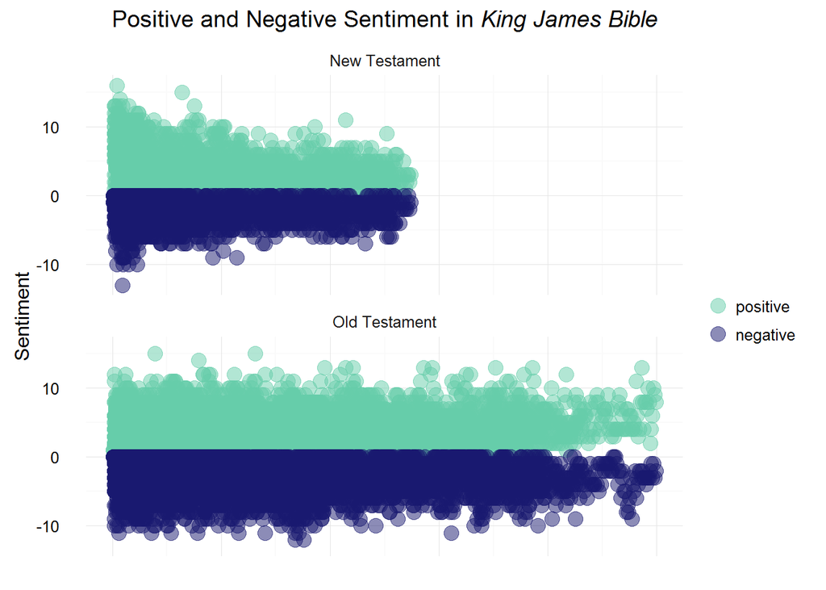

```r
ggplot(data = KJVposneg, aes(x = linenumber, y = value, color = sentiment)) +
  facet_wrap(~testament, nrow = 3) +
  geom_point(size = 4, alpha = 0.5) + theme_minimal() +
  ylab("Sentiment") +
  ggtitle(expression(paste("Positive and Negative Sentiment in ",
                           italic("King James Bible")))) +
  theme(legend.title=element_blank()) +
  theme(axis.title.x=element_blank()) +
  theme(axis.ticks.x=element_blank()) +
  theme(axis.text.x=element_blank()) +
    scale_color_manual(values = c("aquamarine3", "midnightblue"))
```

The as a barchart

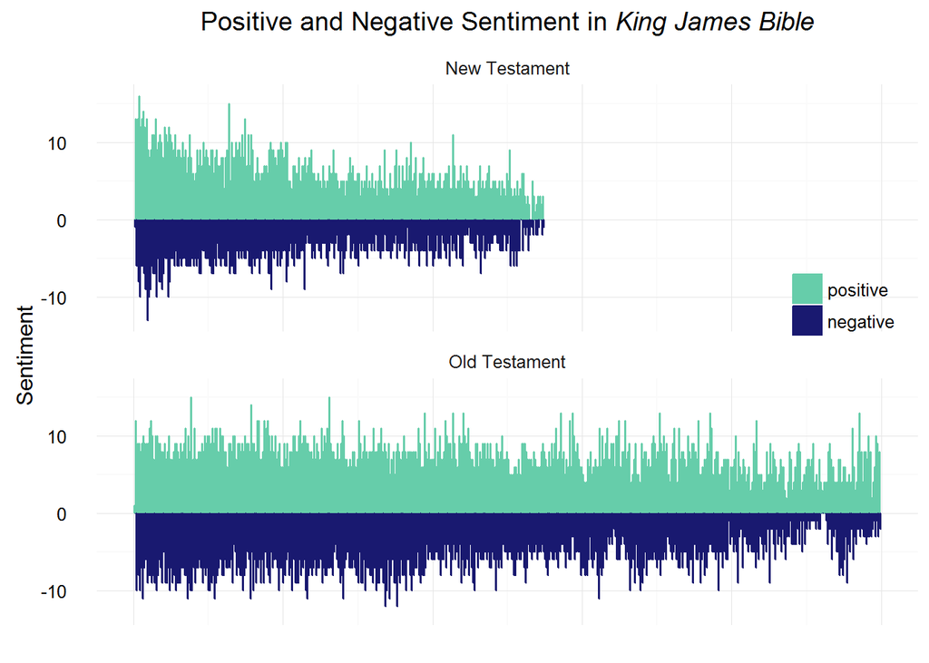

```r
ggplot(data = KJVposneg, aes(x = linenumber, y = value, color = sentiment, fill = sentiment)) +
  facet_wrap(~testament, nrow = 3) +
  geom_bar(stat = "identity", position = "dodge") + theme_minimal() +
  ylab("Sentiment") +
  ggtitle(expression(paste("Positive and Negative Sentiment in ",
                           italic("King James Bible")))) +
  theme(legend.title=element_blank()) +
  theme(axis.title.x=element_blank()) +
  theme(axis.ticks.x=element_blank()) +
  theme(axis.text.x=element_blank()) +
  theme(legend.justification=c(1,1), legend.position=c(1, 0.71))+
  scale_fill_manual(values = c("aquamarine3", "midnightblue")) +
  scale_color_manual(values = c("aquamarine3", "midnightblue"))
```

The we make a new data frame to calculate the fourier transforms This uses get_sentiment() which returns numeric vector of sentiment values, one value for each input sentence, i.e. the (positive - negative) emotion totals.

```r
KJVsentiment <- data.frame(cbind(linenumber = seq_along(chunksKJV), sentiment=get_sentiment(chunksKJV, method = "nrc")))
KJVsentiment$testament <- "Old Testament"
KJVsentiment[BookStart[40]:length(chunksKJV),'testament'] <- "New Testament"
KJVsentiment$testament <- as.factor(KJVsentiment$testament)
```

Plot single sentiment values

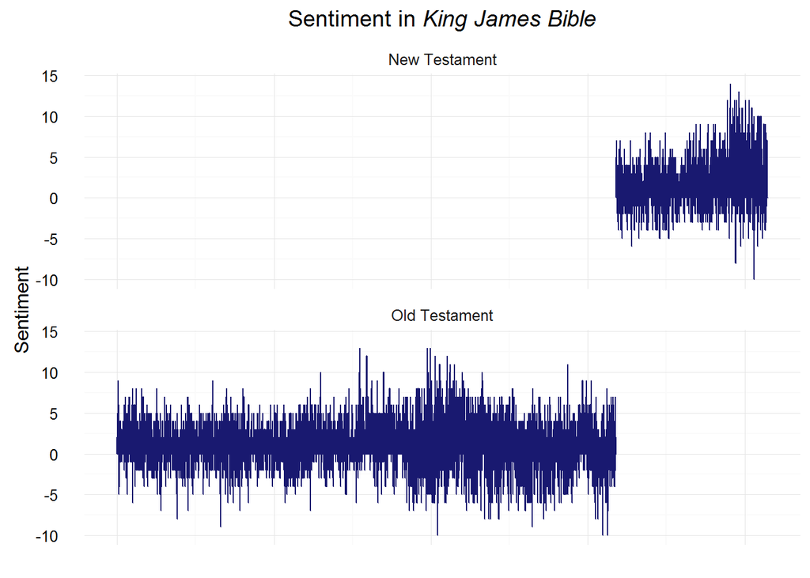

```r
ggplot(data = KJVsentiment, aes(x = linenumber, y = sentiment)) +
  facet_wrap(~testament, nrow = 2) +
  geom_bar(stat = "identity", position = "dodge", color = "midnightblue") +
  theme_minimal() +
  ylab("Sentiment") +
  ggtitle(expression(paste("Sentiment in ", italic("King James Bible")))) +
  theme(axis.title.x=element_blank()) +
  theme(axis.ticks.x=element_blank()) +
  theme(axis.text.x=element_blank()) #+
```

```r
  theme(legend.justification=c(1,1), legend.position=c(1, 0.71))
```

```
## List of 2
##  $ legend.justification: num [1:2] 1 1
##  $ legend.position     : num [1:2] 1 0.71
##  - attr(*, "class")= chr [1:2] "theme" "gg"
##  - attr(*, "complete")= logi FALSE
##  - attr(*, "validate")= logi TRUE
```

get_transformed_values() - Converts input values into a standardized set of filtered and reverse transformed values for easy plotting and/or comparison.

```r
KJVft <- as.numeric(get_transformed_values(KJVsentiment$sentiment,
                                             low_pass_size = 3,
                                             scale_vals = TRUE,
                                             scale_range = FALSE))
KJVft <- data.frame(cbind(linenumber = seq_along(KJVft), ft = KJVft))
View(KJVft)
```

Plot the fourier transforms

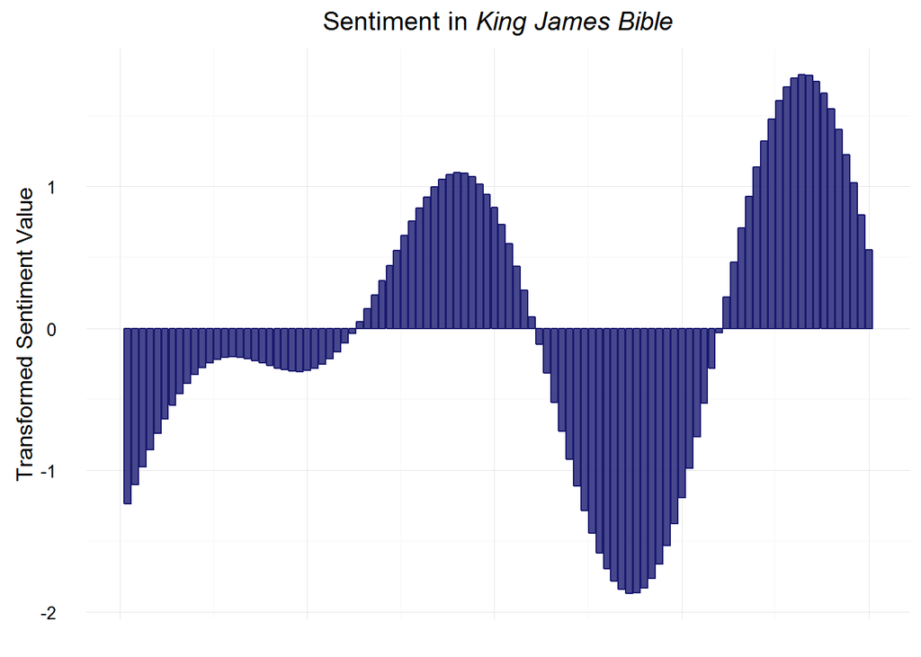

```r
ggplot(data = KJVft, aes(x = linenumber, y = ft)) +
  geom_bar(stat = "identity", alpha = 0.8, color = "midnightblue", fill = "midnightblue") +
  theme_minimal() +
  ylab("Transformed Sentiment Value") +
  ggtitle(expression(paste("Sentiment in ", italic("King James Bible")))) +
  theme(axis.title.x=element_blank()) +
  theme(axis.ticks.x=element_blank()) +
  theme(axis.text.x=element_blank())
```